# Introduction to Spline-DV

Shreyan Gupta, Selim Romero, James J Cai

12 July 2024

#### Abstract

This tutorial shows how to use **Spline-DV** for Differential Variability Analysis across two single-cell RNA seq samples and **Spline-HVG** for highly variable feature selection

# Why to use SplineDV?

## Beyond Averages

One of the most intuitive ways to evaluate a gene expression change is using Differential Expression (DE) analysis. Traditionally, DE analysis focuses on identifying genes that are up- or down-regulated (increased or decreased expression) between conditions, typically employing a basic mean-difference approach. We propose a paradigm shift that acknowledges the central role of gene expression variability in cellular function and challenges the current dominance of mean-based DE analysis in single-cell studies. We suggest that scRNA-seq data analysis should embrace the role of inherent gene expression variability in defining cellular function and move beyond mean-based approaches.

# Installation

```r
if (!require("devtools")) install.packages("devtools")
devtools::install_github("Xenon8778/SplineDV")
```

# Overview of the SplineDV workflow

## Input - Two expression matrix

The expression matrix should be formatted with the genes/features as rows and cells as columns. Ideally, the matrix will be stored in sparse format to save memory.

The two input matrices must be stored in two separate expression matrices or Seurat objects.

```r
# i.e. Reading a Seurat RDS file
exprMatrix <- readRDS('mySingleCellExperiment.rds')

# or .h5 file experiment
exprMatrix <- Seurat::Read10X_h5('mySingleCellExperiment.h5')
```

Loading two separate expression matrices

```r
# i.e. Reading a Seurat RDS file
exprMatrix_1 <- readRDS('mySingleCellExperiment_1.rds')
exprMatrix_2 <- readRDS('mySingleCellExperiment_2.rds')

# or .h5 file experiment
exprMatrix_1 <- Seurat::Read10X_h5('mySingleCellExperiment_1.h5')
exprMatrix_2 <- Seurat::Read10X_h5('mySingleCellExperiment_2.h5')
```

## Loading scRNAseq count example data

The example data is borrowed from an experimental *Nkx2-1* Gene knockout scRNA-seq study by Liebler *et al.* <sup>1</sup>

```r
# Load Data
exprMatrix_WT = read.csv('https://github.com/Xenon8778/SplineDV/raw/main/data/WTdata.csv', row.names = 1) # WT Sample
exprMatrix_KO = read.csv('https://github.com/Xenon8778/SplineDV/raw/main/data/KOdata.csv', row.names = 1) # KO Sample
```

## Running Spline-DV

For the analysis, the test data (X) is always use in contrast with the control data (Y).

```r
library(SplineDV)
DV_res = DV_splinefit(X = exprMatrix_KO, Y = exprMatrix_WT, ncells = 3, nfeatures = 200)
head(DV_res)
```

```
##     genes        mu1       mu2       CV1       CV2     drop1     drop2
## 1    Ager 0.15322875 0.8052301 2.1615822 1.7327735 0.9209979 0.6484375
## 2  S100a6 0.85017354 0.4944678 1.2752928 1.7850222 0.4719335 0.7695312
## 3 Gm42418 2.16955607 0.5321229 0.8490939 0.8771994 0.1185031 0.5429688
## 4  Hspa1a 0.38079484 1.1115697 1.5779693 1.2353369 0.8648649 0.6914062
## 5   Sftpc 0.81406211 2.6303977 1.5871827 1.2093759 0.4116424 0.0000000
## 6  Sftpa1 0.04236689 0.4555925 1.9172147 1.5202991 0.9646570 0.6679688
##       dist1      dist2 Vector_Dist Direction         Pval
## 1 0.1343272 0.73614559    1.627520        -1 2.267700e-38
## 2 0.4379647 0.44809317    1.454774        -1 4.768872e-20
## 3 0.3197114 0.08027716    1.392433         1 6.011969e-15
## 4 0.2594192 0.53454042    1.390657        -1 8.177540e-15
## 5 0.7149476 0.00000000    1.388855         1 1.115612e-14
## 6 0.0000000 0.34923447    1.357046        -1 2.085761e-12
```

## Visualize Gene Expression distributions

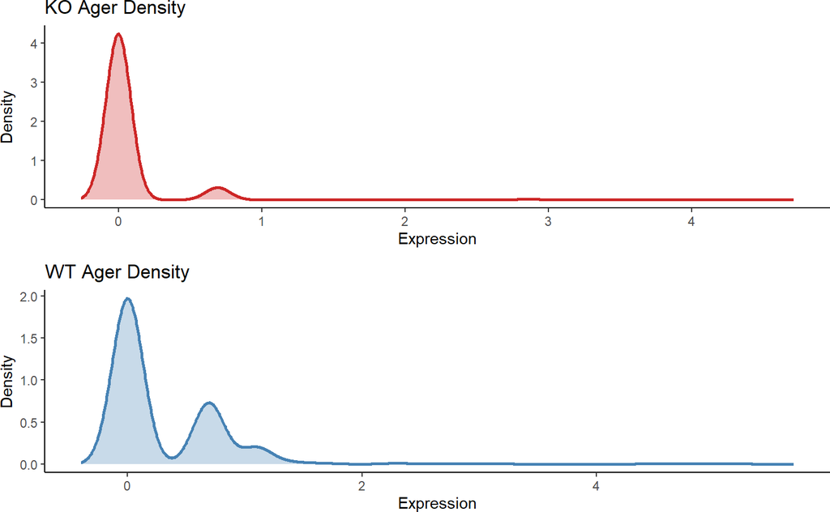

```r
library(MASS)
library(scales)
library(ggplot2)
library(ggpubr)

getdensity <- function(data, gene, col = 'firebrick3',
                       ident = NULL, plot.mu = FALSE){

  dat = log(as.numeric(data[gene,])+1) # Log1p transforming
  dat.line = density(dat)

  df = data.frame(x = dat.line$x, y = dat.line$y, Genotype = ident)
  p1 = ggplot(df, aes(x = x, y = y))+ theme_classic() +
    geom_area(aes(x = x, y = y), color = col,
              fill = alpha(col,0.3), linewidth = 1) +
    labs(x = 'Expression',y = 'Density') +
    ggtitle(paste0(ident,' ',gene, ' Density'))
  if (is.null(legend) == FALSE){
    p1 = p1
    p1
  }
  if (plot.mu == TRUE){
    p1 = p1 + geom_vline(xintercept = log(mean(dat)+1),
                         col = col, lty = 'dashed', linewidth = 1)
  }
  return(p1)
}

gene = 'Ager'
p1 = getdensity(exprMatrix_KO, gene = gene, ident = 'KO')
p2 = getdensity(exprMatrix_WT, gene = gene, col = 'steelblue', ident = 'WT')
ggarrange(p1,p2,ncol = 1, align = 'hv')
```

# Highly Variable Genes (HVGs) using Spline-HVG

## Input - scRNA-seq Expression matrix

```r
# Loading Data
exprMatrix = read.csv('https://github.com/Xenon8778/SplineDV/raw/main/data/WTdata.csv', row.names = 1) # WT Sample
```

## Running Spline-HVG

```r
HVG_res = HVG_splinefit(exprMatrix, nHVGs = 100, ncells = 3, nfeatures = 200)
head(HVG_res)
```

```
##           Means       CV   Dropout   logMean    logCV  Distance nearidx
## Eln    6.397232 3.833013 0.3535156 2.0011059 1.575470 1.0430641      36
## Mgp    1.605275 5.234976 0.8144531 0.9575381 1.830175 0.8840445     823
## Ager   1.231167 4.638383 0.6484375 0.8025246 1.729597 0.7333362     519
## Cxcl12 2.309517 2.736737 0.7031250 1.1968021 1.318213 0.6326307     127
## Fbln5  1.284905 3.191711 0.8046875 0.8263244 1.433109 0.5437679     343
## Hspa1a 2.040132 2.439640 0.6914062 1.1119008 1.235367 0.5349296     133
##            dvecx     dvecy      dvecz   splinex   spliney   splinez  HVG
## Eln    0.1552663 0.9982898  0.2594082 1.0544599 0.8082948 0.3443351 TRUE
## Mgp    0.8479316 0.2280567 -0.1026495 0.2519606 1.2738724 0.8142323 TRUE
## Ager   0.5545421 0.4491521 -0.1689007 0.4765186 1.0085278 0.6362746 TRUE
## Cxcl12 0.2111587 0.4957585  0.3314470 0.4076989 1.0986203 0.7059175 TRUE
## Fbln5  0.4096372 0.3419624  0.1046068 0.2663187 1.2425287 0.7997340 TRUE
## Hspa1a 0.1681020 0.4070066  0.3037055 0.4245463 1.0815710 0.6928794 TRUE
```

```r
# Extracting HVG Gene list
HVG_list = rownames(HVG_res)[HVG_res$HVG == TRUE]
HVG_list
```

```
##   [1] "Eln"           "Mgp"           "Ager"          "Cxcl12"
##   [5] "Fbln5"         "Hspa1a"        "Ier3"          "Car4"
##   [9] "Igfbp7"        "Hmgb2"         "Hspb1"         "S100a6"
##  [13] "Hist1h2bc"     "Vwf"           "Plac8"         "Emp2"
##  [17] "Ube2c"         "Sftpa1"        "Sftpb"         "Lyz2"
##  [21] "Cd24a"         "Fos"           "Bgn"           "Esm1"
##  [25] "Fbln2"         "Cenpa"         "Junb"          "Prss23"
##  [29] "H2afz"         "2810417H13Rik" "Ly6a"          "Pmp22"
##  [33] "Cks2"          "Ctsh"          "Socs3"         "Stmn2"
##  [37] "Phlda1"        "Ltbp4"         "Npc2"          "H19"
##  [41] "H2afx"         "Igfbp4"        "Tuba1b"        "Cyp4b1"
##  [45] "Apln"          "Scgb1a1"       "Birc5"         "Top2a"
##  [49] "Gm26917"       "Tm4sf1"        "Zfp36"         "Ubald2"
##  [53] "Rgcc"          "Wbp5"          "2700094K13Rik" "Rrbp1"
##  [57] "Fibin"         "Hes1"          "H1f0"          "Psap"
##  [61] "Rdx"           "Apold1"        "Sat1"          "Ddit4"
##  [65] "Cpe"           "Marcks"        "Gja4"          "Sptbn1"
##  [69] "Egr1"          "Tspo"          "Cdkn1a"        "Ranbp1"
##  [73] "Hist1h1c"      "Hey1"          "Fabp5"         "Stmn1"
##  [77] "Prkcdbp"       "Rrm2"          "Crip1"         "Flt1"
##  [81] "Timp3"         "Btg2"          "Ednrb"         "Eva1b"
##  [85] "Sparcl1"       "Smarca2"       "Edn1"          "Ran"
##  [89] "Anxa5"         "Pdlim2"        "Prdx6"         "Tmem109"
##  [93] "Anxa2"         "Tpm1"          "Bub3"          "Lrrc8c"
##  [97] "Cenpf"         "Wif1"          "Cyr61"         "Aldoa"
```

# Appendix

## References

1. Liebler JM, Marconett CN, Juul N, et al. Combinations of differentiation markers distinguish subpopulations of alveolar epithelial cells in adult lung. Am J Physiol Lung Cell Mol Physiol. 2016;310(2):L114-L120. doi:10.1152/ajplung.00337.2015

# sessionInfo

This is the output of `sessionInfo()` on the system on which this document was compiled:

```r
date()
```

```
## [1] "Fri Jul 12 11:58:18 2024"
```

```
## R Under development (unstable) (2024-06-03 r86679 ucrt)
## Platform: x86_64-w64-mingw32/x64
## Running under: Windows 11 x64 (build 22631)
##
## Matrix products: default
##
##
## locale:
## [1] LC_COLLATE=C
## [2] LC_CTYPE=English_United States.utf8
## [3] LC_MONETARY=English_United States.utf8
## [4] LC_NUMERIC=C
## [5] LC_TIME=English_United States.utf8
##
## time zone: America/Chicago
```

[output cut: 54 more lines]